# Prediction Assignment Writeup

AGarcia

10/27/2018

# Prediction Assignment Writeup

One thing that people regularly do is quantify how much of a particular activity they do, but they rarely quantify how well they do it. In this project, the goal will be to use data from accelerometers on the belt, forearm, arm, and dumbell of 6 participants.

The goal of this project is to predict the manner in which they did the exercise. This is the “classe” variable in the training set.

## Download dataset in a CourseProject folder and read it

The data for this project come from this source: http://web.archive.org/web/20161224072740/http:/groupware.les.inf.puc-rio.br/har.

More information is available from the website here: http://groupware.les.inf.puc-rio.br/har

```r
if (!file.exists("CourseProject")) {dir.create("CourseProject")}
fileUrl <- "https://d396qusza40orc.cloudfront.net/predmachlearn/pml-training.csv"
download.file(fileUrl, destfile = "./CourseProject/pml-training.csv", method = "curl")
fileUrl <- "https://d396qusza40orc.cloudfront.net/predmachlearn/pml-testing.csv"
download.file(fileUrl, destfile = "./CourseProject//pml-testing.csv", method = "curl")

# read csv
pml_training <- read.csv("./CourseProject/pml-training.csv")
pml_testing <- read.csv("./CourseProject/pml-testing.csv")

# import libraries
library(caret)
library(ggplot2)
library(rattle)
library(klaR)
library(randomForest)
```

## Delete unimportant and NA columns on training and testing data set

Before use the training and testing dataset some fields has been deleted, like NA or DIV/0 as weel as irrelevant fields for the study like the index or user name.

```r
dim(pml_training); dim(pml_testing)
```

```
## [1] 19622   160
```

```
## [1]  20 160
```

```r
pml_training <- subset(pml_training, select = -c(X, user_name, raw_timestamp_part_1, raw_timestamp_part_2, cvtd_timestamp, new_window , num_window, max_roll_belt, max_picth_belt, max_yaw_belt, min_roll_belt, min_pitch_belt, min_yaw_belt, amplitude_roll_belt, amplitude_pitch_belt, amplitude_yaw_belt, var_total_accel_belt, avg_roll_belt, stddev_roll_belt, var_roll_belt, avg_pitch_belt, stddev_pitch_belt, var_pitch_belt, avg_yaw_belt, stddev_yaw_belt, var_yaw_belt, var_accel_arm, avg_roll_arm, stddev_roll_arm, var_roll_arm, avg_pitch_arm, stddev_pitch_arm, var_pitch_arm, avg_yaw_arm, stddev_yaw_arm, var_yaw_arm, max_roll_arm, max_picth_arm, max_yaw_arm, min_roll_arm, min_pitch_arm, min_yaw_arm, amplitude_roll_arm, amplitude_pitch_arm, amplitude_yaw_arm,max_roll_dumbbell, max_picth_dumbbell, max_yaw_dumbbell, min_roll_dumbbell, min_pitch_dumbbell, min_yaw_dumbbell, amplitude_roll_dumbbell, amplitude_pitch_dumbbell,var_accel_dumbbell, avg_roll_dumbbell, stddev_roll_dumbbell, var_roll_dumbbell, avg_pitch_dumbbell, stddev_pitch_dumbbell, var_pitch_dumbbell, avg_yaw_dumbbell, stddev_yaw_dumbbell, var_yaw_dumbbell,max_roll_forearm, max_picth_forearm, max_yaw_forearm, min_roll_forearm, min_pitch_forearm, min_yaw_forearm, amplitude_roll_forearm, amplitude_pitch_forearm, var_accel_forearm, avg_roll_forearm, stddev_roll_forearm, var_roll_forearm, avg_pitch_forearm, stddev_pitch_forearm, var_pitch_forearm, avg_yaw_forearm, stddev_yaw_forearm, var_yaw_forearm, kurtosis_roll_belt, kurtosis_picth_belt, kurtosis_yaw_belt, skewness_roll_belt, skewness_roll_belt.1, skewness_yaw_belt, kurtosis_roll_arm, kurtosis_picth_arm, kurtosis_yaw_arm, skewness_roll_arm, skewness_pitch_arm, skewness_yaw_arm,kurtosis_roll_dumbbell, kurtosis_picth_dumbbell, kurtosis_yaw_dumbbell, skewness_roll_dumbbell, skewness_pitch_dumbbell, skewness_yaw_dumbbell, kurtosis_roll_forearm, kurtosis_picth_forearm, kurtosis_yaw_forearm, skewness_roll_forearm, skewness_pitch_forearm, skewness_yaw_forearm, amplitude_yaw_forearm,amplitude_yaw_dumbbell ))
pml_testing <- subset(pml_testing, select = -c(X, user_name, raw_timestamp_part_1, raw_timestamp_part_2, cvtd_timestamp, new_window , num_window, max_roll_belt, max_picth_belt, max_yaw_belt, min_roll_belt, min_pitch_belt, min_yaw_belt, amplitude_roll_belt, amplitude_pitch_belt, amplitude_yaw_belt, var_total_accel_belt, avg_roll_belt, stddev_roll_belt, var_roll_belt, avg_pitch_belt, stddev_pitch_belt, var_pitch_belt, avg_yaw_belt, stddev_yaw_belt, var_yaw_belt, var_accel_arm, avg_roll_arm, stddev_roll_arm, var_roll_arm, avg_pitch_arm, stddev_pitch_arm, var_pitch_arm, avg_yaw_arm, stddev_yaw_arm, var_yaw_arm, max_roll_arm, max_picth_arm, max_yaw_arm, min_roll_arm, min_pitch_arm, min_yaw_arm, amplitude_roll_arm, amplitude_pitch_arm, amplitude_yaw_arm,max_roll_dumbbell, max_picth_dumbbell, max_yaw_dumbbell, min_roll_dumbbell, min_pitch_dumbbell, min_yaw_dumbbell, amplitude_roll_dumbbell, amplitude_pitch_dumbbell,var_accel_dumbbell, avg_roll_dumbbell, stddev_roll_dumbbell, var_roll_dumbbell, avg_pitch_dumbbell, stddev_pitch_dumbbell, var_pitch_dumbbell, avg_yaw_dumbbell, stddev_yaw_dumbbell, var_yaw_dumbbell,max_roll_forearm, max_picth_forearm, max_yaw_forearm, min_roll_forearm, min_pitch_forearm, min_yaw_forearm, amplitude_roll_forearm, amplitude_pitch_forearm, var_accel_forearm, avg_roll_forearm, stddev_roll_forearm, var_roll_forearm, avg_pitch_forearm, stddev_pitch_forearm, var_pitch_forearm, avg_yaw_forearm, stddev_yaw_forearm, var_yaw_forearm, kurtosis_roll_belt, kurtosis_picth_belt, kurtosis_yaw_belt, skewness_roll_belt, skewness_roll_belt.1, skewness_yaw_belt, kurtosis_roll_arm, kurtosis_picth_arm, kurtosis_yaw_arm, skewness_roll_arm, skewness_pitch_arm, skewness_yaw_arm, kurtosis_roll_dumbbell, kurtosis_picth_dumbbell, kurtosis_yaw_dumbbell, skewness_roll_dumbbell, skewness_pitch_dumbbell, skewness_yaw_dumbbell, kurtosis_roll_forearm, kurtosis_picth_forearm, kurtosis_yaw_forearm, skewness_roll_forearm, skewness_pitch_forearm, skewness_yaw_forearm, amplitude_yaw_forearm,amplitude_yaw_dumbbell ))
dim(pml_training); dim(pml_testing)
```

```
## [1] 19622    53
```

```
## [1] 20 53
```

## Create data partition

Using the training data partition has been done using 70% data for training and 30% for testing.

```r
inTrain <- createDataPartition(y=pml_training$classe,
                               p=0.7, list=FALSE)
training <- pml_training[inTrain,]
testing <- pml_training[-inTrain,]
dim(training); dim(testing)
```

```
## [1] 13737    53
```

```
## [1] 5885   53
```

## Predicting with trees

First approximation has been done using the method rpart, reason for this is because is easy to interpret and get a first basic idea to understand an interpretate the model.

```r
set.seed(32343)
modFitRPART <- train(classe ~., data=training, method="rpart")
modFitRPART
```

```
## CART
##
## 13737 samples
##    52 predictor
##     5 classes: 'A', 'B', 'C', 'D', 'E'
##
## No pre-processing
## Resampling: Bootstrapped (25 reps)
## Summary of sample sizes: 13737, 13737, 13737, 13737, 13737, 13737, ...
## Resampling results across tuning parameters:
##
##   cp          Accuracy   Kappa
##   0.03641542  0.5143558  0.36759260
##   0.06004815  0.4249218  0.22202768
##   0.11728207  0.3152967  0.04551775
##
## Accuracy was used to select the optimal model using the largest value.
## The final value used for the model was cp = 0.03641542.
```

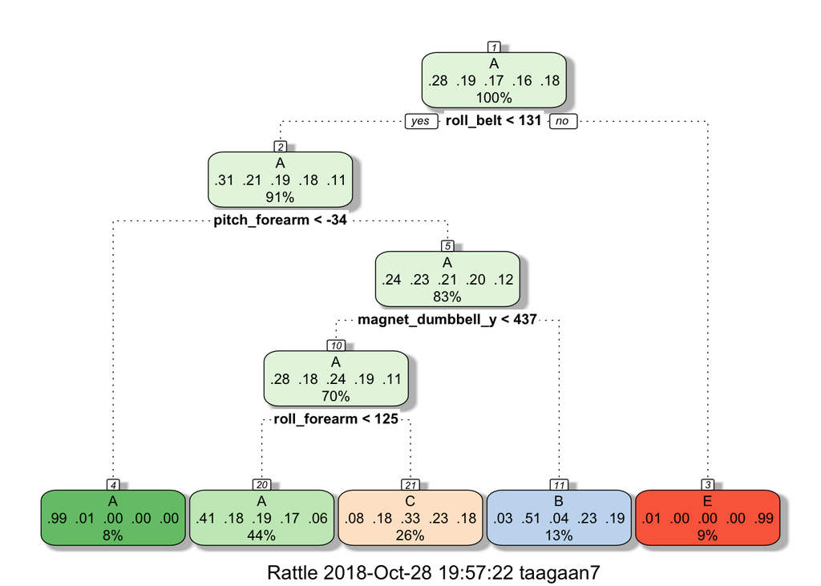

```r
## fancy plot
fancyRpartPlot(modFitRPART$finalModel)
```

```r
# predict new values
predRPART <- predict(modFitRPART,newdata=testing)
cmRPART <- confusionMatrix(predRPART, testing$classe)$overall[1]
cmRPART
```

```
##  Accuracy
## 0.4922685
```

Using Predicting with trees, the acuracy if very small.

## Random Forest

Second method used is Ramdom Forest, as positive aspect is that normaly get a very good accuracy but nevertheless is a very slow method due the construction of multitude decision trees.

```r
#modFitRF <- train(classe~ .,data=training,method="rf",prox=TRUE)
modFitRF <- randomForest(classe~ .,data=training,type = "class")
print(modFitRF)
```

```
##
## Call:
##  randomForest(formula = classe ~ ., data = training, type = "class")
##                Type of random forest: classification
##                      Number of trees: 500
## No. of variables tried at each split: 7
##
##         OOB estimate of  error rate: 0.44%
## Confusion matrix:
##      A    B    C    D    E class.error
## A 3902    3    0    0    1 0.001024066
## B    7 2647    4    0    0 0.004138450
## C    0   17 2377    2    0 0.007929883
## D    0    0   19 2232    1 0.008880995
## E    0    0    2    5 2518 0.002772277
```

```r
predRF <- predict(modFitRF,newdata=testing)
cmRF <- confusionMatrix(predRF, testing$classe)$overall[1]
table(predRF,testing$classe)
```

```
##
## predRF    A    B    C    D    E
##      A 1673    5    0    0    0
##      B    0 1132    3    0    0
##      C    1    2 1022   12    0
##      D    0    0    1  951    3
##      E    0    0    0    1 1079
```

```r
cmRF
```

```
##  Accuracy
## 0.9952421
```

Using Random Forest, accuracy is very hight especially for Class A and Class E.

## Boosting

Next method used is Boosting

```r
modFitGBM <- train(classe ~ ., method="gbm",data=training,verbose=FALSE)
print(modFitGBM)
```

```
## Stochastic Gradient Boosting
##
## 13737 samples
##    52 predictor
##     5 classes: 'A', 'B', 'C', 'D', 'E'
##
## No pre-processing
## Resampling: Bootstrapped (25 reps)
## Summary of sample sizes: 13737, 13737, 13737, 13737, 13737, 13737, ...
## Resampling results across tuning parameters:
##
##   interaction.depth  n.trees  Accuracy   Kappa
##   1                   50      0.7522206  0.6858688
##   1                  100      0.8151598  0.7660672
##   1                  150      0.8478355  0.8074466
##   2                   50      0.8508064  0.8109974
##   2                  100      0.9026493  0.8768079
##   2                  150      0.9275900  0.9083856
##   3                   50      0.8914855  0.8626200
##   3                  100      0.9380950  0.9216836
##   3                  150      0.9574217  0.9461416
##
## Tuning parameter 'shrinkage' was held constant at a value of 0.1
##
## Tuning parameter 'n.minobsinnode' was held constant at a value of 10
## Accuracy was used to select the optimal model using the largest value.
## The final values used for the model were n.trees = 150,
##  interaction.depth = 3, shrinkage = 0.1 and n.minobsinnode = 10.
```

```r
predGBM <- predict(modFitGBM,testing)
cmRF <- confusionMatrix(predGBM, testing$classe)$overall[1]
table(predGBM,testing$classe)
```

```
##
## predGBM    A    B    C    D    E
##       A 1648   20    0    0    0
##       B   13 1093   32    6   11
##       C   10   23  980   26    8
##       D    3    1   13  926   22
##       E    0    2    1    6 1041
```

```r
cmRF
```

```
##  Accuracy
## 0.9665251
```

Accuracy for Boosting is hight, but it does not surpass the accuray acquire with Random Forest.

## Model based prediction

Las tecnique used is a Model based prediction

```r
##Build predictions
modLDA = train(classe ~ .,data=training,method="lda")
modNB = train(classe ~ ., data=training,method="nb")
```

```r
table(predLDA,predNB)
```

```
##        predNB
## predLDA    A    B    C    D    E
##       A 1462   48   89   72   29
##       B  109  755   94   68  133
##       C  359   54  642   31   55
##       D  237   32  131  642   89
##       E   27  106   16   42  563
```

# Conclusion

Best method is Random Forest.

```r
pml_testing <- subset(pml_testing, select = -c(problem_id))
final_pred <- predict(modFitRF, pml_testing, type = "class")
final_pred
```

```
##  1  2  3  4  5  6  7  8  9 10 11 12 13 14 15 16 17 18 19 20
##  B  A  B  A  A  E  D  B  A  A  B  C  B  A  E  E  A  B  B  B
## Levels: A B C D E
```